# Milestone 01 - Group 09

Daniel Hadley, Kristina Wright

February 29, 2020

## Airbnb Listings for Barcelona

### Introduction

Airbnb, Inc. is a company founded in 2008 that offers an online marketplace connecting people who offer lodging with people who require accomodations in that locale. The company does not own any of the listed properties and operates as a broker, collecting commissions once a lodging is booked. As a direct competitor to hotels, we are interested in how the users listing properties determine the price they charge.

When accomodations are offered through Airbnb, the person listing the property is called a host, and they must provide a variety of information about the listing including price, neighborhood, type of accommodations offered, and the minimum number of nights a guest must stay if they want to make a booking. In addition to information provided by the host, Airbnb collects and disseminates information about the listing which we use to perform our analysis.

The data is collected using public information compiled from the Airbnb website. Specific collection techniques are not specified, though the Inside Airbnb [website](http://insideairbnb.com/behind.html) states that it uses Open Source technologies such as D3, Boostrap, jQuery, etc. to collect the data and much code was “copied and pasted” from the internet. A major contributer to this code, [Tom Slee](http://tomslee.net/category/airbnb-data), described it as a “scrape” of the Airbnb website for each city.

### Data Description

The [dataset](http://insideairbnb.com/get-the-data.html) used in this analysis is collected and offered by Inside Airbnb, an independent, non-commercial project started by Murray Cox and John Morris. Their goal is to allow people to see how Airbnb might be affecting the residential housing market. We use the summary data for listings, since it includes the data we are interested in exploring and is more manageable, size-wise, than the detailed listings data.

The data used in this analysis was compiled on November 9, 2019 and includes 20,428 Airbnb listings that travellers see when using the Airbnb website to find accommodations in Barcelona, Spain. The table below describes the available data for each listing in the dataset.

[output not shown]

### Exploring the Dataset

#### Remove Unwanted Data

In this section, we remove columns from the dataset that should have no fundamental influence on listing price. This includes the short title of th listing (`name`), the name of the host(s) (`host_name`), and the availability of the listing over the next 365 days (`availability_365`). While there might end up being a relation between availability and price, since cheap listings for a desirable neighbourhood are likely to be booked, this relationship is backwards; we want to find factors that affect the listing price, not factors affected by the listing price.

#### Rename Columns

Some of the column names are a little long, so we perform the following renamings:

- `neighbourhood_group` is renamed to `district`
- `minimum_nights` is renamed to `min_stay`
- `number_of_reviews` is renamed to `reviews`
- `calculated_host_listings_count` is renamed to `host_listings`

#### Price Density

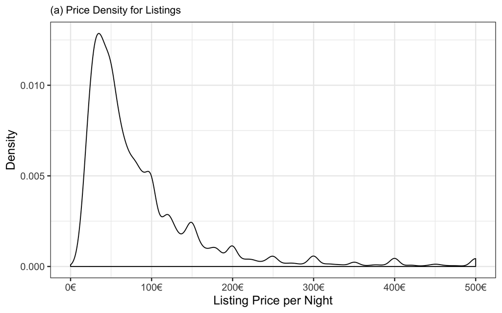

#### Correlogram

Based on the correlogram shown below there is little correlation between the 6 numerical variables presented. All positive correlations are in blue, and all negative correlations are in red.

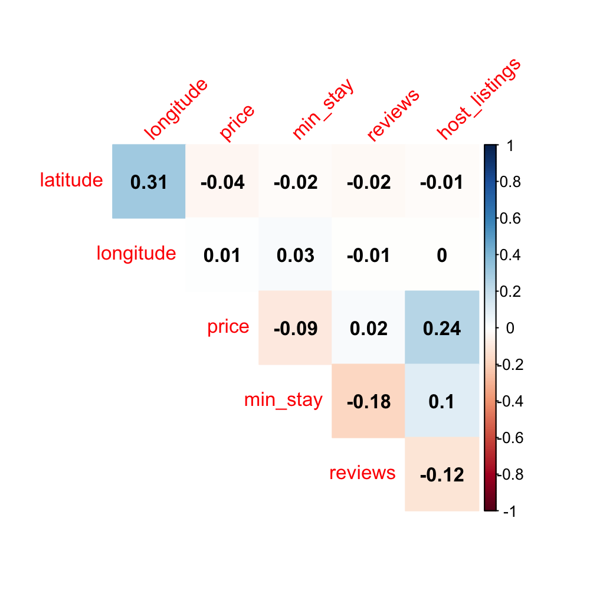

#### Violin Plot

The violin plot below shows the distribution of price in log10 scale for each district in descending order of average price. Based on the plot, Eixample has the highest priced and Nou Barris has the lowest priced listings.

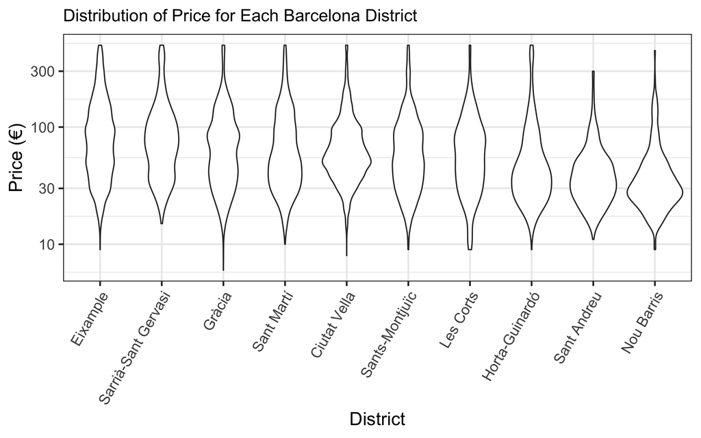

### Research Question

In this analysis, we determine which factors, such as listing neighbourhood, type of room, distance from city center, etc. are significantly related to the price of a listing.

### Plan of Action

With our research question, the first goal is to determine which factors are most important to explaining list price and perform a linear regression analysis. This may require some data transformation, handling or removal of outliers, and removing incomplete observations.

### References

[Airbnb dataset](http://insideairbnb.com/get-the-data.html)